# Quantized models support

8.1.0  
Quantized models support

# Quantized models support

X-CUBE-AI Expansion Package

r1.0

AI PLATFORM r8.1.0 (Embedded Inference Client API 1.2.0)

Command Line Interface r1.7.0

**References**

[1] “A Survey of Quantization Methods for Efficient Neural Network Inference” - https://arxiv.org/abs/2103.13630v3

[2] “Quantization and Training of Neural Networks for Efficient Integer-Arithmetic-Only Inference” - https://arxiv.org/abs/1712.05877

# Overview

The X-CUBE-AI code generator can be used to deploy a quantized model. In this article, “Quantization” refers to 8 bit linear quantization of a NN model (Note that X-CUBE-AI provides also a support for the pre-trained Deep Quantized Neural Network (DQNN) model, see “Deep Quantized Neural Network (DQNN) support” [DQNN] article).

Quantization is an optimization technique [[1]](https://arxiv.org/abs/2103.13630v3) to compress a 32-bit floating-point model by reducing the size (smaller storage size and less memory peak usage at runtime), by improving CPU/MCU usage and latency (including power consumption) with a small degradation of accuracy. A quantized model executes some or all of the operations on tensors with integers rather than floating point values. It is an important part of various optimization techniques: topology-oriented, features-map reduction, pruning, weights compression.. which can be applied to address the resource-constrained runtime environment.

There are two classical methods of quantization: post-training quantization (PTQ) and quantization aware training (QAT). First is relatively easier to use, it allows to quantize a pre-trained model with a limited and representative data set (also called calibration data set). Quantization aware training is done during the training process and is often better for model accuracy.

X-CUBE-AI can import different type of quantized model:

- a **quantized TensorFlow lite model** generated by a post-training or training aware process. The calibration has been performed by the TensorFlow Lite framework, principally through the “TFLite converter” utility exporting a TensorFlow lite file.
- a **quantized ONNX model** based on the Operator-oriented (QOperator) or the Tensor-oriented (QDQ; Quantize and DeQuantize) format. The first format is dependent of the supported QOperators (see the *QLinearXXX* operators, [ONNX]), and the second is more generic. The DeQuantizeLinear(QuantizeLinear(tensor)) operators are inserted between the original operators (in float) to simulate the quantization and dequantization process. Both formats can be generated with the ONNX runtime services.

[figure not shown]

For optimization and performance reasons, the deployed C-kernel (specialized C-implementation of the deployed operators) support only the quantized weights and quantized activations. If this pattern is not infered by the optimizing and rendering passes of the code generator, a floating-point version of the operator is deployed (fallback to 32-b floating point with inserted QUANTIZE/DEQUANTIZE operators, aka fake/simulated quantization). Subsequently:

- the **dynamic** quantization approach allowing to compute the quantization parameters during the execution is *NOT* supported to limit the overhead and the cost of the inference in term of computation and memory peak usage
- support of the **mixed** models is considered

The “analyze”, “validate” and “generate” commands can be used w/o limitations.

```powershell
$ stm32ai analyze -m <quantized_model_file>.tflite
$ stm32ai validate -m <quantized_model>.tflite -vi test_data.npz
$ stm32ai analyze -m <quantized_model_file>.onnx
```

**Note** — The CLI integrates an internal *deprecated* post-training quantization process (refer to “Quantize command” article) for an already-trained Keras model.

## Quantized tensors ([[1]](https://arxiv.org/abs/2103.13630v3), [[2]](https://arxiv.org/abs/1712.05877))

X-CUBE-AI supports the 8b integer-base (*int8* or *uint8* data type) arithmetic for the quantized tensors which are based on the representative convention used by Google for the quantized models ([[2]](https://arxiv.org/abs/1712.05877)). Each real number *r* is represented in function of the quantized value *q*, a *scale* factor (*arbitrary positive real number*) and a *zero_point* parameter. Quantization scheme is an affine mapping of the integers *q* to real numbers *r*. *zero_point* has the same integer C-type like the *q* data.

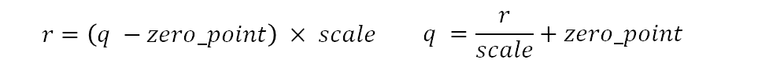

The precision is dependent of a *scale* factor and the quantized values are linearly distributed around the *zero_point* value. In both case, resolution/precision is constant vs floating-point representation.

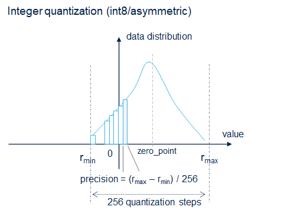

Integer precision

**Info** — For the code generator, quantized tensors are defined as a container storing the quantized data, represented as int8/uint8/int32 C-array and the quantization parameters: *scale* and *zero-point* values. These parameters are statically defined in the tensor C-structure definition, `ai_tensor` object (part of the generated `'<network>.c'` file) and the data are stored in the `'<network>_data.c'` file.

### Per-axis (or per-channel or channelwise) vs per-tensor (or layerwise)

Per-tensor means that the same format (i.e. *scale*/*zero_point*) is used for the entire tensor (weights are activations). Per-axis for conv-base operator means there will be one *scale* and/or *zero_point* per filter, independent of the others channels, ensuring a better quantization (accuracy point of view) with negligible computation overhead.

**Per-axis** approach is currently the standard method used for quantized convolutionnal kernels (weight tensors). Activation tensors are always in **per-tensor**. Design of the optimzed C-kernels is mainly drived by this approach.

### Symmetric vs Asymmetric

*Asymmetric* means that the tensor can have *zero_point* anywhere within the signed 8b range [-128, 127] or unsigned 8b range [0, 255]. *Symmetric* means that the tensor is forced to have *zero_point* equal to zero. By enforcing *zero_point* to zero, some kernel optimization implementations are possible to limit the cost of the operations (off-line pre-calculation..). By nature, the activations are asymmetric, consequently symmetric format for the activations is not supported. For the weights/bias, asymmetric and symmetric format are supported.

### Signed integer vs Unsigned integer - supported schemes

Signed or unsigned integer type can be defined for the weights and/or activations. However all requested kernels are not implemented or relevant to support the different optimized combinations related to the symmetric and asymmetric format. This imply that *only* the following integer schemes or combinations are supported:

| scheme | weights | activations |
| --- | --- | --- |
| ua/ua | unsigned and asymmetric | unsigned and asymmetric |
| ss/sa | signed and symmetric | signed and asymmetric |
| ss/ua | signed and symmetric | unsigned and asymmetric |

# Quantize Tensorflow models

X-CUBE-AI is able to import the quantization training-aware and post-training quantized TensorFlow lite models. Post-training quantized models (TensorFlow v1.15 or v2.x) are based on the “ss/sa” and per-channel scheme. Activations are asymmetric and signed (int8), weights/bias are symmetric and signed (int8). Previous quantized training-aware models are based on the “ua/ua” scheme, now the “ss/sa” and per-channel scheme is also the privileged scheme to address efficiently the [Coral Edge TPUs](https://coral.ai/docs/edgetpu/models-intro/#compatibility-overview) or [TensorFlow Lite for Microcontrollers](https://www.tensorflow.org/lite/microcontrollers) runtime.

## Supported/recommended methods

- Post-training quantization: https://www.tensorflow.org/lite/performance/post_training_quantization
- Quantization aware training: https://www.tensorflow.org/model_optimization/guide/quantization/training

| method/option | supported/recommended |
| --- | --- |
| Dynamic range quantization | not supported, only static approach is considered |
| Full integer quantization | **supported**, representative dataset should be used for the calibration |
| Integer with float fallback (using default float input/output) | supported, mixed model, representative dataset should be used for the calibration |
| Integer only | **recommended**, representative dataset should be used for the calibration |
| Weight Only Quantization | not supported |
| Input/output data type | `'uint8'`, `'int8'` and `'float32'` can be used |
| Float16 quantization | not supported, only float32 model are supported |
| Per Channel | default behavior, can be not modified |
| Activation type | `'int8'`, “ss/sa” scheme |
| Weight type | `'int8'`, “ss/sa” scheme |

## “Integer only” method

The following code snippet illustrates the recommended *TFLiteConverter* options to *enforce* full integer scheme (post-training quantization for all operators including the input/output tensors).

```python
def representative_dataset_gen():
  data = tload(...)

  for _ in range(num_calibration_steps):
    # Get sample input data as a numpy array in a method of your choosing.
    input = get_sample(data)
    yield [input]

converter = tf.lite.TFLiteConverter.from_saved_model(<saved_model_dir>)
# converter = tf.lite.TFLiteConverter.from_keras_model(model)
converter.representative_dataset = representative_dataset_gen
# This enables quantization
converter.optimizations = [tf.lite.Optimize.DEFAULT]
# This ensures that if any ops can't be quantized, the converter throws an error
converter.target_spec.supported_ops = [tf.lite.OpsSet.TFLITE_BUILTINS_INT8]
# These set the input and output tensors to int8
converter.inference_input_type = tf.int8  # or tf.uint8
converter.inference_output_type = tf.int8  # or tf.uint8
quant_model = converter.convert()

# Save the quantized file
with open(<tflite_quant_model_path>, "wb") as f:
    f.write(quant_model)
...
```

## “Full integer quantization” method

As the mixed models are supported by X-CUBE-AI, the full integer quantization method can be used. However, it is also preferable to enable the TensorFlow Lite ops (`TFLITE_BUILTINS`) as only a limited number of TensorFlow operators are supported (see the supported [TFLITE] operators).

```python
...
converter = tf.lite.TFLiteConverter.from_saved_model(<saved_model_dir>)
# converter = tf.lite.TFLiteConverter.from_keras_model(model)
converter.representative_dataset = representative_dataset_gen
# This enables quantization
converter.optimizations = [tf.lite.Optimize.DEFAULT]
# This optional option, ensures that TF Lite operators are used.
converter.target_spec.supported_ops = [tf.lite.OpsSet.TFLITE_BUILTINS]
# These set the input and output tensors to float32
converter.inference_input_type = tf.float32  # or tf.uint8, tf.int8
converter.inference_output_type = tf.float32  # or tf.uint8, tf.int8
quant_model = converter.convert()
...
```

**Note** — Quantization of the input or/and output tensors are optional. They can be conserved in float for convenience and deployment facility, for example to keep the pre or/and post-processes in float.

## Warning - Usage of the tf.lite.Optimize.DEFAULT

This option enables the quantization process. However, to be sure to have the quantized weights and quantized activations, `representative_dataset` attribute should be *always* used. Else only the weights/params will be quantized allowing to reduce the size of the generated file by ~4. But in this case, as for the deprecated option (OPTIMIZE_FOR_SIZE), the tflite file will be deployed as a fully floating-point c-model with the weights in float (dequantized values).

Note that this option should be not used to convert a TensorFlow model.

# Quantize ONNX models

- https://onnxruntime.ai/docs/performance/quantization.html

To quantize a ONNX model, it is recommended to use the services from the [ONNX runtime module](https://onnxruntime.ai/docs/performance/quantization.html). The Tensor-oriented (QDQ; Quantize and DeQuantize) format is privileged, as illustrated by the following figure, the additional DeQuantizeLinear(QuantizeLinear(tensor)) between the original operators will be automatically detected and removed to deploy the associated optimized C-kernels.

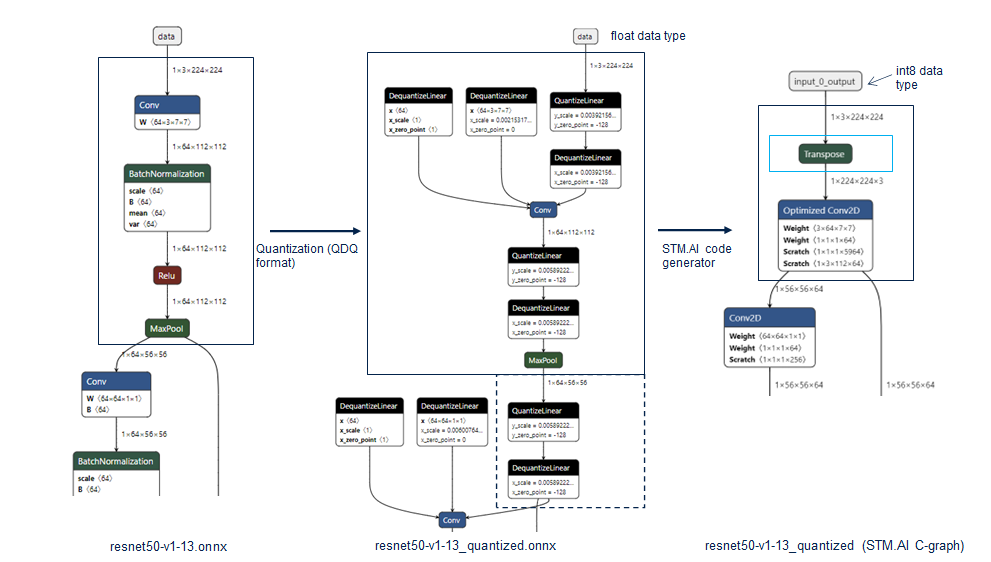

**Comments** about the illustrated example:

- merging of the Batch Normalization operators is automatically done by the `quantize` function. Model can be also previously optimized for inference before to quantize the model (ONNX Simplifier can be also used)

  ```
    $ python -m onnxruntime.quantization.preprocess --input model.onnx --output model-infer.onnx
  ```

- as the deployed C-kernels are *channel last* (“hwc” data format) and to respect the original input data representation, a `'Transpose'` operator has been added. Note that this operation is done by SW and the cost can be not negligeable. To avoid this situation, the option ‘–no-onnx-io-transpose’ can be used, allowing to process directly w/o transpose operation.
- by **default**, the IO data type (float32) of the original ONNX model is not conserved if they are quantized by the first *QuantizeLinear* operator (respectively dequantized by the last *DeQuantizeLinear* operator). As illustrated in the following figure, to keep the IO in float, the option `'--onnx-keep-io-as-model'` can be used.

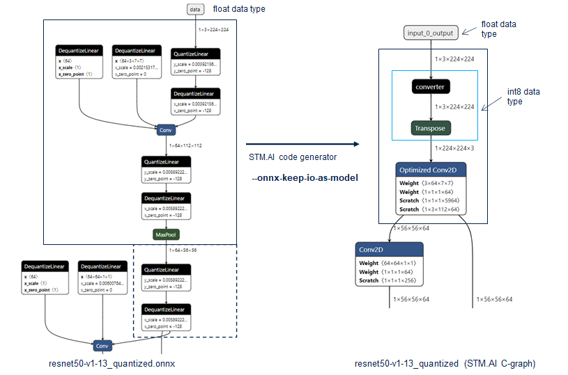

## Supported/recommended methods/options

| method/option | supported/recommended |
| --- | --- |
| Dynamic quantization | not supported, only static approach is considered |
| Static Quantization | **recommended**, representative dataset should be used for the calibration |
| Quant format | `'QuantFormat.QDQ'` is **recommended**, `'QuantFormat.QOperator'` is not recommended (not tested, and limited supported *QLinearXXX* operators, [ONNX]) |
| Activation type | `'QuantType.QInt8'` is **recommended** (default), `'QuantType.QUInt8'` is not recommended and *not tested* |
| Weight type | `'QuantType.QInt8'` is **recommended** (default), `'QuantType.QUInt8'` is not recommended and *not tested* |
| Calibration Method | `'CalibrationMethod.MinMax'`, `'CalibrationMethod.Entropy'` and `'CalibrationMethod.Percentile'` can be used |
| Per Channel | **recommended**: `True`, *per tensor* (= `False`) is also supported |
| nodes_to_exclude/nodes_to_quantize | supported, the mixed models can be deployed by X-CUBE-AI |

## “Static Quantization” method

The following code snippet illustrates a typical Python script (post-training quantization) to quantize a NN model processing the images (classifier or object-detector applications). It is based on the [end-to-end example](https://github.com/microsoft/onnxruntime-inference-examples/blob/main/quantization/image_classification/cpu/run.py) from [*“Quantize ONNX Models”*](https://onnxruntime.ai/docs/performance/quantization.html) article. Note that only the inputs (images used for the calibration) are requested and the associated data can be transposed (hwc to chw) to be conform to the expected input data representation.

```python
import numpy
import onnxruntime
from onnxruntime.quantization import QuantFormat, QuantType, StaticQuantConfig, quantize, CalibrationMethod
from onnxruntime.quantization import CalibrationDataReader
from PIL import Image

input_model_path = 'my_model.onnx'
output_model_path = 'my_model_quantized.onnx'

calibration_dataset_path = '/path/to/data/for/calibration'

def _preprocess_images(images_folder: str, height: int, width: int):
    """
    Load a batch of images and preprocess them..
    """
    image_names = os.listdir(images_folder)
    batch_filenames = image_names
    unconcatenated_batch_data = []

    for image_name in batch_filenames:
        image_filepath = images_folder + "/" + image_name
        pillow_img = Image.new("RGB", (width, height))
        pillow_img.paste(Image.open(image_filepath).resize((width, height)))
        input_data = numpy.float32(pillow_img) - numpy.array(
            [123.68, 116.78, 103.94], dtype=numpy.float32
        )
        nhwc_data = numpy.expand_dims(input_data, axis=0)
        nchw_data = nhwc_data.transpose(0, 3, 1, 2)  # ONNX Runtime standard
        unconcatenated_batch_data.append(nchw_data)
    batch_data = numpy.concatenate(
        numpy.expand_dims(unconcatenated_batch_data, axis=0), axis=0
    )
    return batch_data

class XXXDataReader(CalibrationDataReader):
    def __init__(self, calibration_image_folder: str, model_path: str):
        self.enum_data = None

        # Use inference session to get input shape.
        session = onnxruntime.InferenceSession(model_path, None)
        (_, _, height, width) = session.get_inputs()[0].shape

        # Convert image to input data
        self.nhwc_data_list = _preprocess_images(
            calibration_image_folder, height, width)

        self.input_name = session.get_inputs()[0].name
        self.datasize = len(self.nhwc_data_list)

    def get_next(self):
        if self.enum_data is None:
            self.enum_data = iter(
                [{self.input_name: nhwc_data} for nhwc_data in self.nhwc_data_list]
            )
        return next(self.enum_data, None)

    def rewind(self):
        self.enum_data = None

dr = XXXDataReader(
        calibration_dataset_path, input_model_path
    )

conf = StaticQuantConfig(
    calibration_data_reader=dr,
    quant_format=QuantFormat.QDQ,
    calibrate_method=CalibrationMethod.MinMax,
    optimize_model=True,
    activation_type=QuantType.QInt8,
    weight_type=QuantType.QInt8,
    # nodes_to_exclude=['resnetv17_dense0_fwd', ..],
    # nodes_to_quantize=['resnetv17_dense0_fwd', ..],
    per_channel=True)

quantize(infer_model,
    output_model_path, conf)
```

Note that for a quick evaluation in term of inference time and memory footprint, the `XXXDataReader` object can be updated to generate the *fake* image with the random data.

```python
import numpy

class XXXDataReader(CalibrationDataReader):
    def __init__(self, calibration_image_folder: str, model_path: str):
        self.enum_data = None

        # Use inference session to get input shape.
        session = onnxruntime.InferenceSession(model_path, None)
        (_, chnannel, height, width) = session.get_inputs()[0].shape

        # Generate the random data in the half-open interval [0.0, 1.0).
        self.nhwc_data_list = [np.random.random_sample((1, chnannel, height, width)).astype(np.float32)
                               for i in range(20)]

        self.input_name = session.get_inputs()[0].name
        self.datasize = len(self.nhwc_data_list)

    def get_next(self):
        if self.enum_data is None:
            self.enum_data = iter(
                [{self.input_name: nhwc_data} for nhwc_data in self.nhwc_data_list]
            )
        return next(self.enum_data, None)

    def rewind(self):
        self.enum_data = None
```

## Requested ONNX Opset

Models must be **opset10** or higher to be quantized. Models with opset < 10 must be reconverted to ONNX from their original framework using a later opset. However, to perform some advanced optimizations (BN folding…), it is recommended to use **opset13**.

```python
import onnx

original_model_path = 'original_model.onnx'
new_model_path = 'new_model.onnx'

new_opset = 13

onnx_model = onnx.load(original_model_path)
converted_model = onnx.version_converter.convert_version(onnx_model, new_opset)
onnx.save(converted_model, new_model_path)
```

## ONNX Simplifier

- https://github.com/daquexian/onnx-simplifier

Before to quantize the ONNX model, it is possible to simplify the model to have an efficient ONNX inference model before quantization or deployment.

```powershell
$ onnxsim my_model.onnx my_simplified_model.onnx --overwrite-input-shape 1,3,224,224
```

## Known limitation

```
Assertion failed: n_channel_in == ( (ai_shape_dimension*)((((&((p_tensor_weights)->shape))))->data) )[(0x0)],
file <root_file_location>\layers_conv2d_stm32_integer.c, line 3628
```

# Quantize Pytorch models

- https://pytorch.org/docs/stable/quantization.html

Pytorch model (Python and `.pth` files) is not *natively* supported by X-CUBE-AI. To be able to deploy it, the model should be converted to ONNX format (with fixed dimensions, batch size = 1, *see following code snippet*). To quantize a Pytorch model, it is currently recommended to use the ONNX runtime services. Pytorch provides an initial beta version of a [quantization API](https://pytorch.org/docs/stable/quantization.html) *but* the generated quantized model can be not currently exported to a “standard” ONNX format importable by X-CUBE-AI.

- https://pytorch.org/tutorials/advanced/super_resolution_with_onnxruntime.html

```python
import torch.onnx
from torch import nn

torch_model = MyPytorchModel(..)

dummy_input = torch.randn(1, 3, 224, 224) # fixed dimension
input_names = [ "actual_input" ]
output_names = [ "output" ]

torch.onnx.export(
    torch_model, # pytorch model (with the weights)
    dummy_input, # model input (or a tuple for multiple inputs)
    "my_model.onnx", # where to save the model
    do_constant_folding=True, # whether to execute constant folding for optimization
    input_names=input_names, # the model's input names
    output_names=output_names, # the model's output names
    opset_version=13, # the ONNX version to export the model to
    export_params=True, # store the trained parameter weights
    verbose=False
    )
```

# References

| ref | description |
| --- | --- |
| [DS] | X-CUBE-AI - AI expansion pack for STM32CubeMX https://www.st.com/en/embedded-software/x-cube-ai.html |
| [UM] | User manual - Getting started with X-CUBE-AI Expansion Package for Artificial Intelligence (AI) [(pdf)](https://www.st.com/resource/en/user_manual/dm00570145.pdf) |
| [CLI] | stm32ai - Command Line Interface (link) |
| [API] | Embedded inference client API (link) |
| [METRIC] | Evaluation report and metrics (link) |
| [TFL] | TensorFlow Lite toolbox (link) |
| [KERAS] | Keras toolbox (link) |
| [ONNX] | ONNX toolbox (link) |
| [ONNX-ML] | Machine Learning support (ONNX-ML operators) (link) |
| [DQNN] | Deep Quantized Neural Network support (link) |
| [FAQS] | FAQ generic, validation, quantization |
| [QUANT] | Quantization (link) |
| [QUANT_CMD] | Quantization Command (link) |
| [RELOC] | Relocatable binary network support (link) |
| [CUST] | Support of the Keras Lambda/custom layers (link) |
| [TFLM] | TensorFlow Lite for Microcontroller support (link) |
| [INST] | Setting the environment (link) |
| [OBS] | Platform Observer API (link) |
| [C-RUN] | Executing locally a generated c-model (link) |
| [BREAK] | API Breaking changes (link) |
| [CRC] | STM32 CRC IP as shared resource (link) |